# Avances 2.3

Andre Jo 22199

2025-03-14

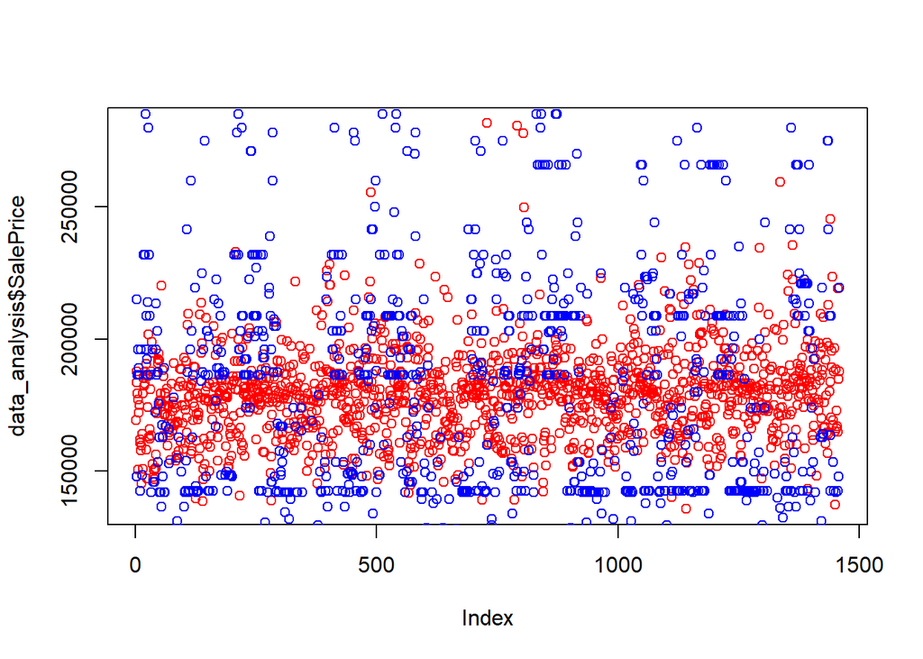

Observamos que en la parte inferior se observa un patrón de overfitting pero en la parte de arriba no tanto. Además de eso, el modelo acertó pocas veces con la concentración de datos que existe en el rango de SalesPrice de 150,000 a 200,000.

```r
EMA <- (mean(data_analysis$SalePrice-predBayes, na.rm = T)^2)
EMA
```

```
## [1] 141211223
```

```r
RMSE <- sqrt(mean((data_analysis$SalePrice - predBayes)^2, na.rm = TRUE))
RMSE
```

```
## [1] 70237.08
```

A comparación del RMSE del modelo Naive Bayes, observamos que pertenece al rango de los modelos presentados anteriormente. (entrega pasada)

```r
modeloRF1<-randomForest(SalePrice~.,data=train)
prediccionRF1<-predict(modeloRF1,newdata = datos)
rmseModelo10test<-RMSE(prediccionRF1,mergeprice)
mseModelo10test<-mean((prediccionRF1 - mergeprice)^2)

prediccionRF1Train<-predict(modeloRF1,newdata = datos)
rmseModelo10train<-RMSE(prediccionRF1Train,train$SalePrice)
mseModelo10train<-mean((prediccionRF1Train - train$SalePrice)^2)
mseModelo10test
```

```
## [1] 4754193898
```

```r
rmseModelo10test
```

```
## [1] 68950.66
```

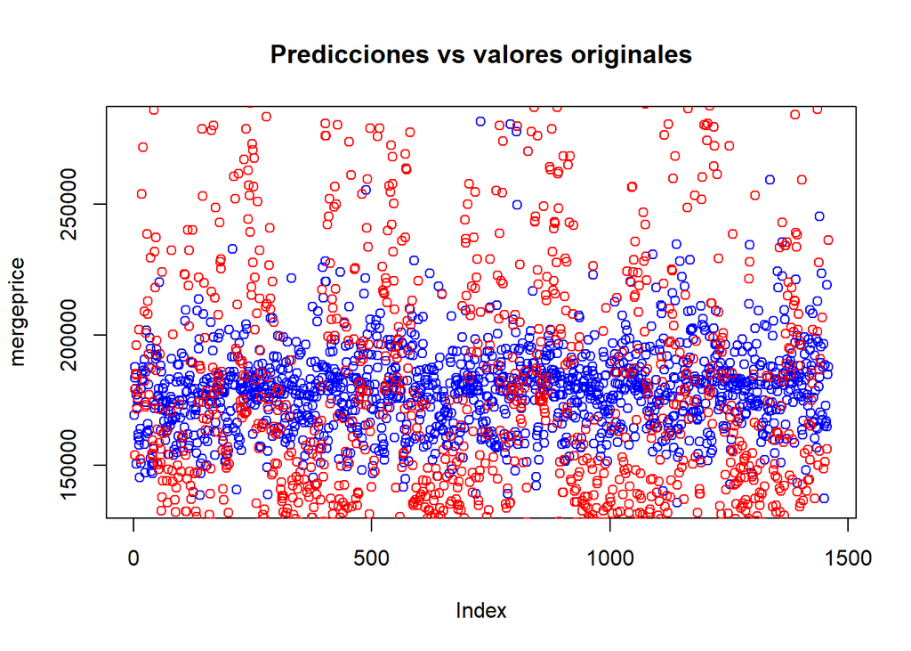

```r
plot(mergeprice,col="blue", main="Predicciones vs valores originales")
points(prediccionRF1, col="red")
legend(30,45,legend=c("original", "prediccion"),col=c("blue", "red"),pch=1, cex=0.8)
```

De las entregas anteriores, se puede obeservar que la gráfica que más relación tiene es el modelo de Random Forest ya que no es un modelo que este presente el overfitting de los datos.